# Homework 4

Mahima Mahajan

2025-01-18

# **EID :** mkm4582

# **[GitHub repo link (CLICK)](https://github.com/mahimaKmahajan/SDS_315_HW4)**

# **Problem 1.** Iron Bank

**Null hypothesis:** The security trades from the Iron Bank are flagged at the same 2.4% baseline rate as that of other traders.

**Test statistic:** 70. The test statistic represents the number of flagged traders at Iron Bank in 2021 by SEC’s detection algorithm.

**Plot of probability distribution of test statistic:**

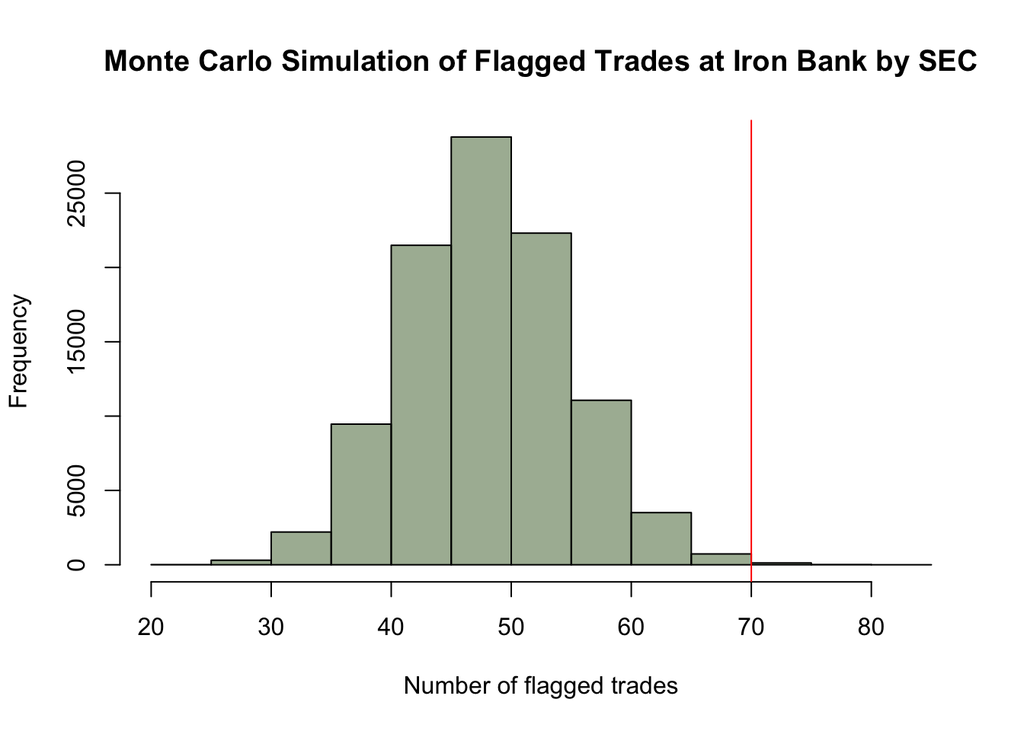

**p-value:** 0.00198

**Conclusion:** Because 0.00198 is significantly lesser than 0.05, we reject the null hypothesis. This suggests that employees at Iron Bank are flagged at a much higher rate than the SEC’s 2.4% baseline rate

# **Problem 2.** health inspections

**Null hypothesis:** The observed data for Gourmet Bites is consistent with the Health Department’s null hypothesis that, on average, restaurants in the city are cited for health code violations at the same 3% baseline rate.

**Test Statistic:** 8. The number of observed health code violations.

**Plot of probability distribution of test statistic:**

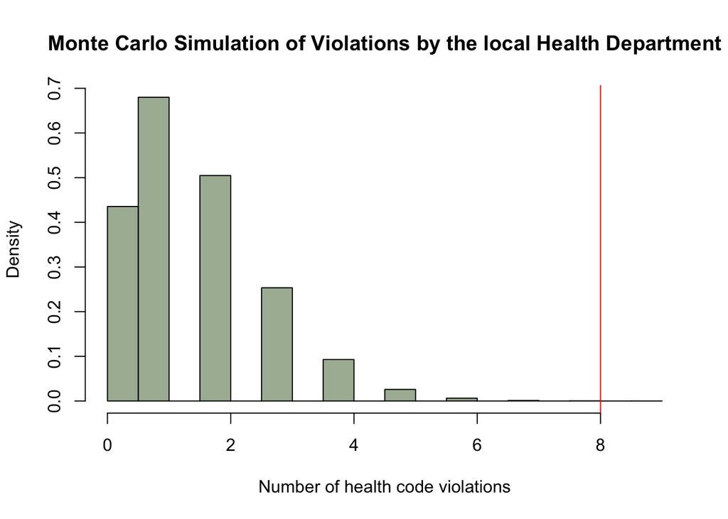

**p-value:** 0.00015

**Conclusion:** Because 0.00015 is significantly lesser than 0.05, we reject the null hypothesis. This suggests that Gourmet Bites has a higher health code violation rate than the local Health Department’s data of a 3% average baseline rate.

# **Problem 3.** Evaluating Jury Selection for Bias

**Ho:** The racial distribution of jurors empaneled by this judge matches the distribution of the eligible jury pool from the population proportions.

**T:** For this test, the test statistic is chi-squared.

**P(T|Ho):**

```
##
##  Chi-squared test for given probabilities
##
## data:  jury_cts
## X-squared = 12.426, df = 4, p-value = 0.01445
```

# **Problem 4.** LLM Watermarking

## Part B: checking for a watermark